# R Notebook

## Main text

#### summary stats quoted in the manuscript

[output not shown]

```
## Surveillance data from the Marshfield Clinic dated back to the 2007-2008 season. In total, 16378 individuals were enrolled between the 2007-2008 season and the 2018-2019 season and contributed 24399 visits.
```

```
##  Among these 15459 individuals were included in the main analyses that study the impact of clinical infection. These individuals contributed 21188 visits.
```

```
##  Among the 9390 current season vaccinees 0.7840256 (n= 7362 ) were also vaccinated in the previous season, and 0.9093717 (n= 8539 vaccinated in at least one of the three seasons immediately before the enrollment season.
```

#### Plot Fig 1：Impact of waning influenza vaccine effectiveness within a season

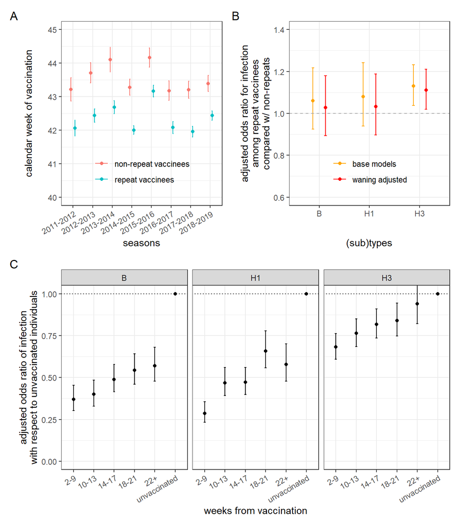

#### Plot Fig2: Impact of clinical infections on the estimated effect of repeated vaccination among participants from the Marshfield Clinic.

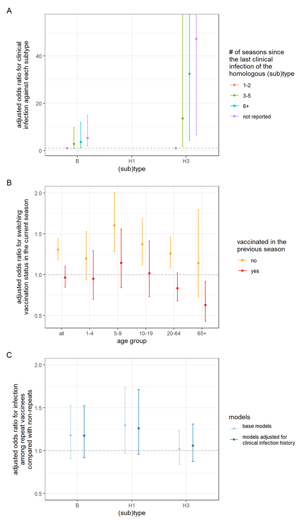

#### Plot Fig 3: Impact of subclinical infection

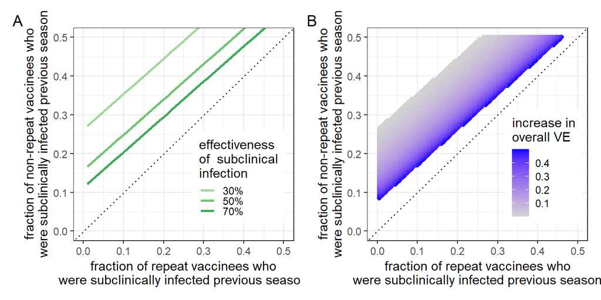

## Supplementary material

#### Stable1: Summary stat of FluVE data

|  | A/H1N1 non-repeat | A/H1N1 repeat | A/H3N2 non-repeat | A/H3N2 repeat | B non-repeat | B repeat | no known clinical infection non-repeat | no known clinical infection repeat |
| --- | --- | --- | --- | --- | --- | --- | --- | --- |
|  | (N=297) | (N=933) | (N=853) | (N=2687) | (N=315) | (N=877) | (N=5891) | (N=16133) |
| **age group** |  |  |  |  |  |  |  |  |
| 0-4 | 28 (9.4%) | 93 (10.0%) | 77 (9.0%) | 243 (9.0%) | 27 (8.6%) | 66 (7.5%) | 848 (14.4%) | 3,091 (19.2%) |
| 5-9 | 32 (10.8%) | 125 (13.4%) | 91 (10.7%) | 302 (11.2%) | 47 (14.9%) | 129 (14.7%) | 514 (8.7%) | 1,447 (9.0%) |
| 10-19 | 14 (4.7%) | 42 (4.5%) | 123 (14.4%) | 392 (14.6%) | 56 (17.8%) | 109 (12.4%) | 682 (11.6%) | 1,413 (8.8%) |
| 20-64 | 197 (66.3%) | 489 (52.4%) | 463 (54.3%) | 1,001 (37.3%) | 152 (48.3%) | 353 (40.3%) | 3,246 (55.1%) | 6,474 (40.1%) |
| 65+ | 26 (8.8%) | 184 (19.7%) | 99 (11.6%) | 749 (27.9%) | 33 (10.5%) | 220 (25.1%) | 601 (10.2%) | 3,708 (23.0%) |
| **sex** |  |  |  |  |  |  |  |  |
| female | 173 (58.2%) | 557 (59.7%) | 510 (59.8%) | 1,596 (59.4%) | 198 (62.9%) | 520 (59.3%) | 3,695 (62.7%) | 9,879 (61.2%) |
| male | 124 (41.8%) | 376 (40.3%) | 343 (40.2%) | 1,091 (40.6%) | 117 (37.1%) | 357 (40.7%) | 2,196 (37.3%) | 6,254 (38.8%) |
| **comorbidities** |  |  |  |  |  |  |  |  |
| no | 173 (58.2%) | 460 (49.3%) | 499 (58.5%) | 1,191 (44.3%) | 196 (62.2%) | 374 (42.6%) | 3,405 (57.8%) | 7,571 (46.9%) |
| yes | 124 (41.8%) | 473 (50.7%) | 354 (41.5%) | 1,496 (55.7%) | 119 (37.8%) | 503 (57.4%) | 2,486 (42.2%) | 8,562 (53.1%) |
| **weeks from vaccination to symptom onset** |  |  |  |  |  |  |  |  |
| 2-9 | 39 (13.1%) | 84 (9.0%) | 214 (25.1%) | 436 (16.2%) | 51 (16.2%) | 84 (9.6%) | 1,461 (24.8%) | 2,810 (17.4%) |
| 10-13 | 56 (18.9%) | 187 (20.0%) | 201 (23.6%) | 633 (23.6%) | 45 (14.3%) | 119 (13.6%) | 1,269 (21.5%) | 3,266 (20.2%) |
| 14-17 | 59 (19.9%) | 228 (24.4%) | 200 (23.4%) | 719 (26.8%) | 73 (23.2%) | 198 (22.6%) | 1,311 (22.3%) | 3,910 (24.2%) |
| 18-21 | 85 (28.6%) | 258 (27.7%) | 149 (17.5%) | 529 (19.7%) | 86 (27.3%) | 230 (26.2%) | 1,034 (17.6%) | 3,445 (21.4%) |
| 22+ | 58 (19.5%) | 176 (18.9%) | 89 (10.4%) | 370 (13.8%) | 60 (19.0%) | 246 (28.1%) | 816 (13.9%) | 2,702 (16.7%) |
| **mean calendar week of vaccination** |  |  |  |  |  |  |  |  |
|  | 42.9 | 42.3 | 42.9 | 41.7 | 43.2 | 42.3 | 43.6 | 42.4 |

#### Stable2: Summary stat of Marshfield data

A/H1N1

A/H3N2

B

no known clinical infection

non-repeat

repeat

non-repeat

repeat

non-repeat

repeat

non-repeat

repeat

(N=61)

(N=355)

(N=162)

(N=813)

(N=56)

(N=286)

(N=1138)

(N=4850)

**age group**

0-4

7 (11.5%)

38 (10.7%)

23 (14.2%)

96 (11.8%)

7 (12.5%)

25 (8.7%)

205 (18.0%)

1,080 (22.3%)

5-9

17 (27.9%)

54 (15.2%)

28 (17.3%)

99 (12.2%)

17 (30.4%)

49 (17.1%)

170 (14.9%)

556 (11.5%)

10-19

3 (4.9%)

19 (5.4%)

32 (19.8%)

118 (14.5%)

10 (17.9%)

31 (10.8%)

225 (19.8%)

498 (10.3%)

20-64

33 (54.1%)

191 (53.8%)

65 (40.1%)

279 (34.3%)

20 (35.7%)

113 (39.5%)

462 (40.6%)

1,805 (37.2%)

65+

1 (1.6%)

53 (14.9%)

14 (8.6%)

221 (27.2%)

2 (3.6%)

68 (23.8%)

76 (6.7%)

911 (18.8%)

**sex**

male

29 (47.5%)

135 (38.0%)

79 (48.8%)

313 (38.5%)

26 (46.4%)

118 (41.3%)

447 (39.3%)

1,923 (39.6%)

female

32 (52.5%)

220 (62.0%)

83 (51.2%)

500 (61.5%)

30 (53.6%)

168 (58.7%)

691 (60.7%)

2,927 (60.4%)

**comorbidities**

no

42 (68.9%)

202 (56.9%)

104 (64.2%)

394 (48.5%)

44 (78.6%)

119 (41.6%)

776 (68.2%)

2,650 (54.6%)

yes

19 (31.1%)

153 (43.1%)

58 (35.8%)

419 (51.5%)

12 (21.4%)

167 (58.4%)

362 (31.8%)

2,200 (45.4%)

**weeks from vaccination to symptom onset**

2-9

13 (21.3%)

22 (6.2%)

38 (23.5%)

129 (15.9%)

17 (30.4%)

29 (10.1%)

221 (19.4%)

558 (11.5%)

10-13

16 (26.2%)

67 (18.9%)

31 (19.1%)

159 (19.6%)

4 (7.1%)

42 (14.7%)

222 (19.5%)

934 (19.3%)

14-17

8 (13.1%)

104 (29.3%)

44 (27.2%)

251 (30.9%)

18 (32.1%)

63 (22.0%)

298 (26.2%)

1,298 (26.8%)

18-21

20 (32.8%)

97 (27.3%)

32 (19.8%)

170 (20.9%)

9 (16.1%)

79 (27.6%)

240 (21.1%)

1,256 (25.9%)

22+

4 (6.6%)

65 (18.3%)

17 (10.5%)

104 (12.8%)

8 (14.3%)

73 (25.5%)

157 (13.8%)

804 (16.6%)

**number of seasons one had been vaccinated in the 2 seasons immediately before the previous season**

0

24 (39.3%)

27 (7.6%)

59 (36.4%)

78 (9.6%)

27 (48.2%)

19 (6.6%)

570 (50.1%)

829 (17.1%)

1

19 (31.1%)

72 (20.3%)

55 (34.0%)

130 (16.0%)

13 (23.2%)

41 (14.3%)

307 (27.0%)

1,168 (24.1%)

2

18 (29.5%)

256 (72.1%)

48 (29.6%)

605 (74.4%)

16 (28.6%)

226 (79.0%)

261 (22.9%)

2,853 (58.8%)

**number of seasons since the last known PCR-confirmed clinical infection of the homologous (sub)type**

1-2

0 (0.0%)

0 (0.0%)

0 (0.0%)

0 (0.0%)

1 (1.8%)

0 (0.0%)

3-5

0 (0.0%)

1 (0.3%)

3 (1.9%)

0 (0.0%)

1 (1.8%)

2 (0.7%)

6+

1 (1.6%)

1 (0.3%)

0 (0.0%)

13 (1.6%)

1 (1.8%)

7 (2.4%)

not reported

60 (98.4%)

353 (99.4%)

159 (98.1%)

800 (98.4%)

53 (94.6%)

277 (96.9%)

**mean calendar week of vaccination**

45.1

43.2

43.5

42.3

44.7

42.6

44.5

43.0

#### SFig3.1: Waning vaccine protection by subtype, season, and site.

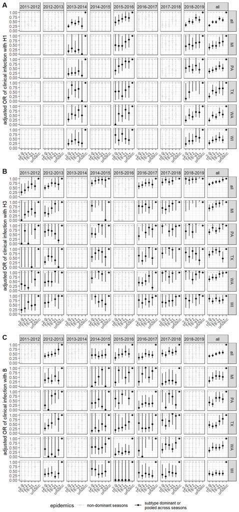

#### SFig3.2: Estimated effect of repeated vaccination by age group

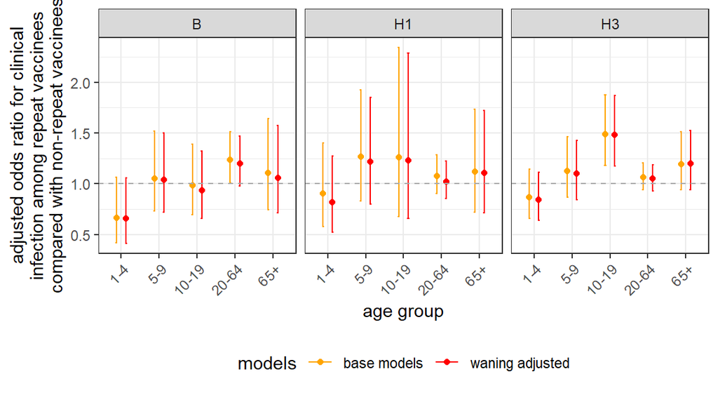

#### SFig3.3: Repeat vaccination effect by season and site

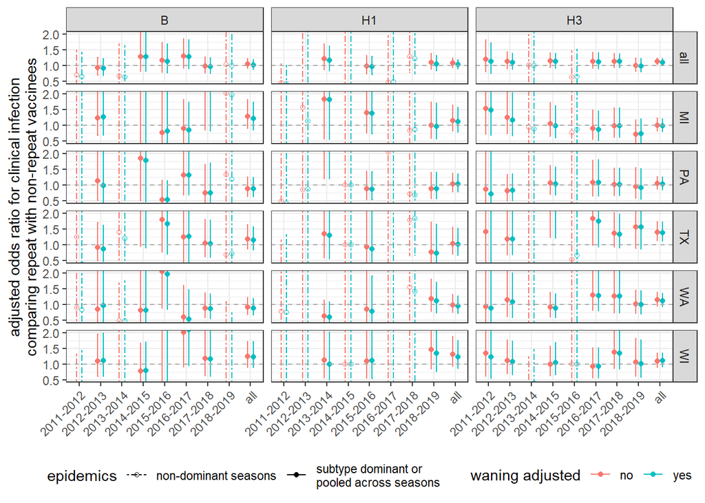

#### SFig3.4: Impact of waning protection before and after excluding individuals vaccinated after the start of a season

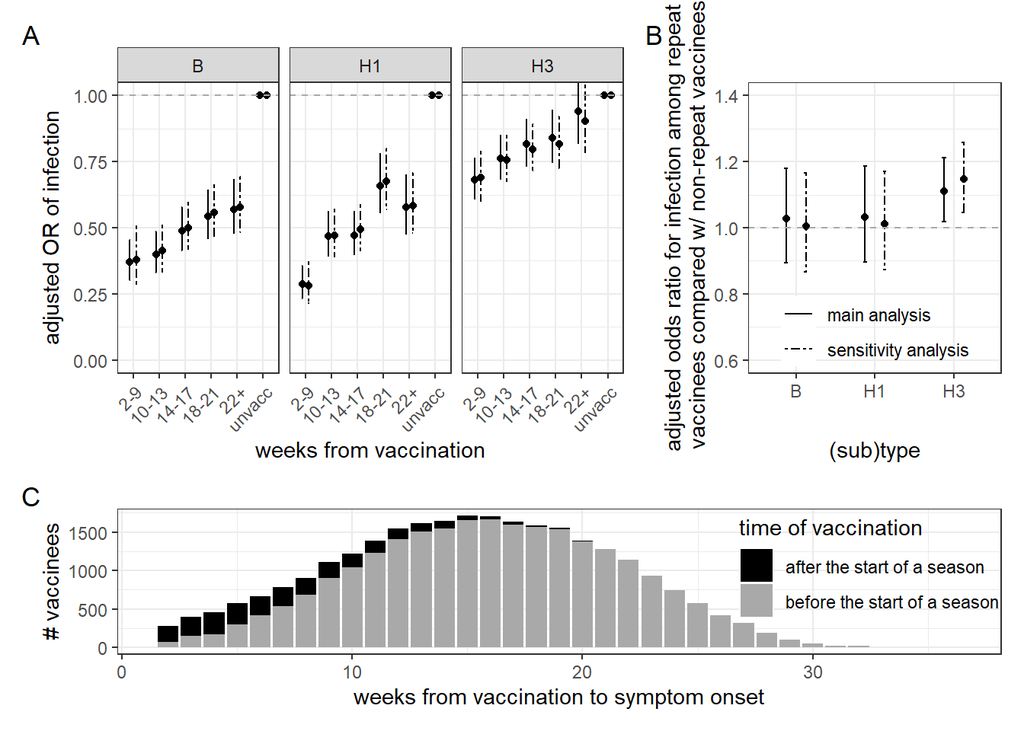

#### sFig4.1: Odds of infection by years since the last clinical infection of the heterologous subtype

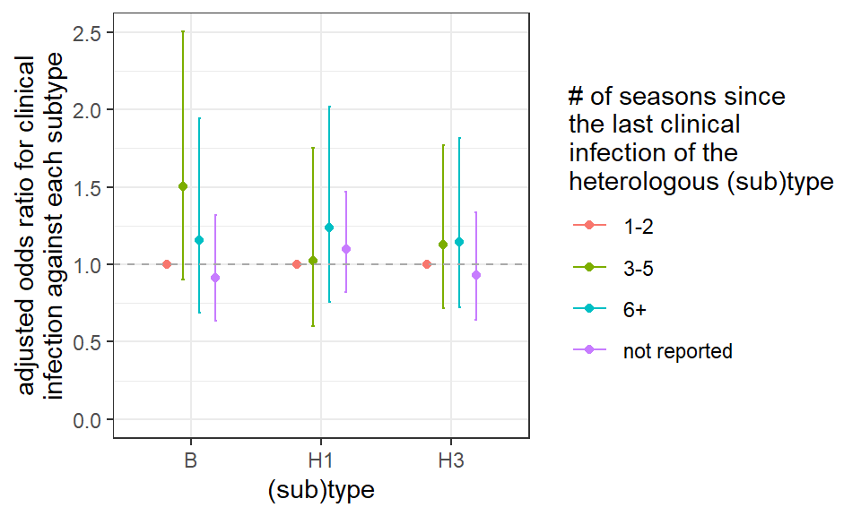

#### SFig4.2: Regenerate figure 2 after excluding those who presented with acute respiratory illness but refused enrollment in the previous season

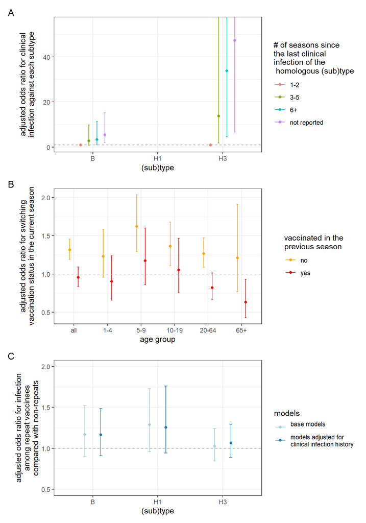

#### SFig4.3: aOR for clinical infection comparing repeat and non-repeat before and after adjusting for waning protection in the weighted outcome models

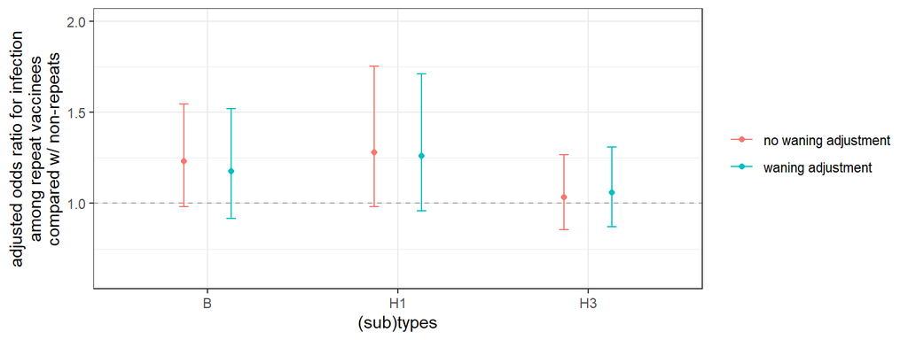

#### SFig4.4: Age-stratified version of Figure 2c

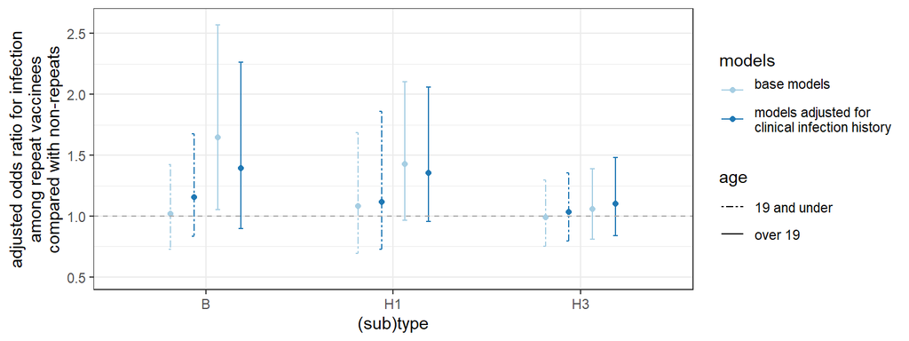

#### SFig 5.1: Test the infection block hypothesis

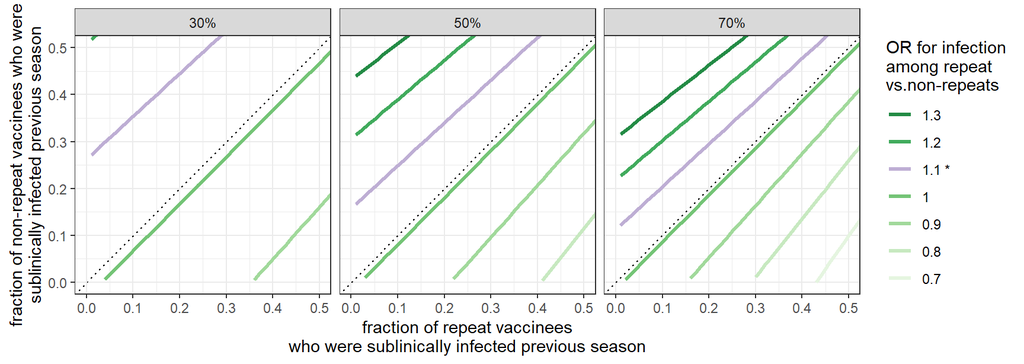

#### SFig5.2: Similar to Fig 5.1 but using parameters that resemble values from high incidence settings

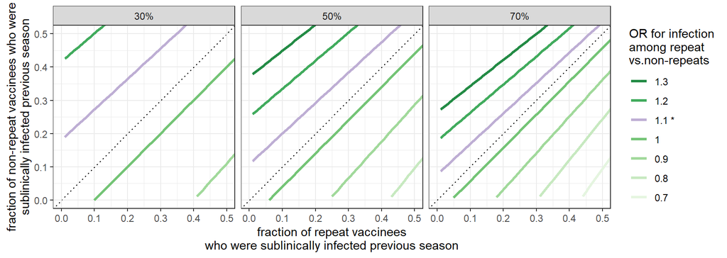

#### SFig 5.3: Test the enhanced vaccine immunogenicity hypothesis

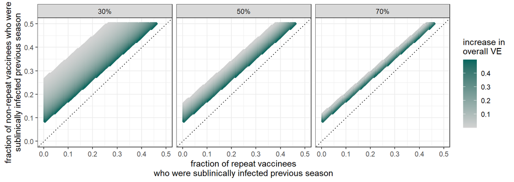

#### SFig6.1: Prior-season clinical infection is unlikely to be an important mediator between prior-season vaccination and current-season clinical infection

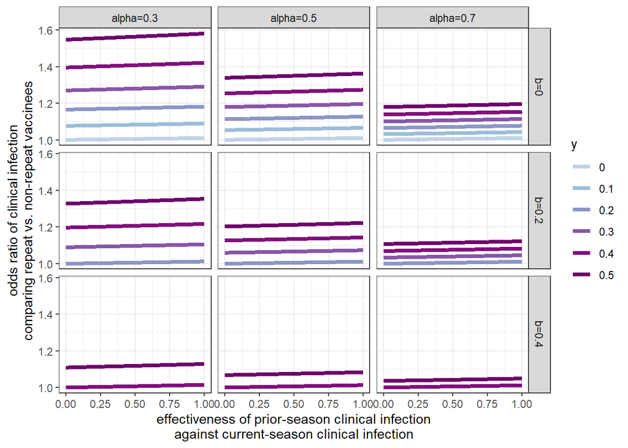